# Homework #4

Dustin Leatherman

4/26/2020

# 5

> Consider the linear congruential random number generator with $M = 17$, and $a$ possibly equal to 3, 4, or 5. Which one of these values of $a$ would be best?

$a$ is defined as a primary root of M and it should ideally be the *largest* primary root of M. $a$ is considered a primary root if $a^i \ mod \ M > 0$ for $i = 1,2,...,M-1$.

```r
M = 17
3^seq(1:M - 1) %% 17
```

```
##  [1]  3  9 10 13  5 15 11 16 14  8  7  4 12  2  6  1  3
```

```r
4^seq(1:M - 1) %% 17
```

```
##  [1]  4 16 13  1  4 16 13  1  4 16 13  1  4 16 13  1  4
```

```r
5^seq(1:M - 1) %% 17
```

```
##  [1]  5  8  6 13 14  2 10 16 12  9 11  4  3 15  7  1  5
```

# 6

> The Poisson Random Variable is a discrete random variable that models how many taxis come by in a fixed time, or how many charged particles are detected in a fixed time, or how hard drive crashes in a fixed time. The probability mass function of the Poisson Random Variable with mean (and variance) $\lambda$ is
> $$f(x) = \begin{cases} \frac{\lambda^x e^{-\lambda}}{x!}, & x = 0,1,...\\ 0, & else \end{cases}$$
> Write an R program to generate i.i.d Poisson Random Variables with mean one, $X_1,...,X_n$ from uniform random variables, $Z_1,...,Z_n$, using the inverse distribution transformation method. Use your program to print out $Z_1, ..., Z_n$ and $X_1, ..., X_n$ for n = 10

```r
n <- 10
x <- runif(n)
z <- qpois(x, 1)
```

X = 0.9471768, 0.4550195, 0.6897229, 0.2723932, 0.2483255, 0.3208907, 0.1476671, 0.2105365, 0.5455134, 0.6073124

Z = 3, 1, 1, 0, 0, 0, 0, 0, 1, 1

# 7

> Consider a distribution with CDF
> $$F(y) = \frac{1}{1 + e^{-y}}, \ y \in R$$
> Use the inverse distribution transformation method to generate random variables with the above CDF from U[0,1] random variables. Generate 1000 such random numbers.

```r
n <- 1000
cdf <- function (y) 1 / (1 + exp(-y))

# analytical derivative of PDF
pdf <- function(y) exp(-y) / (1 + exp(-y))^2

# compute first derivative programmatically for PDF
computed.pdf <- D(expression(1 / (1 + exp(-y))), "y")

x <- runif(n)
y <- cdf(x)
y1 <- pdf(y)
y2 <- eval(computed.pdf)

assertthat::are_equal(y1,y2)
```

```
## [1] TRUE
```

The PDF calculated by R and by hand yield the same results.

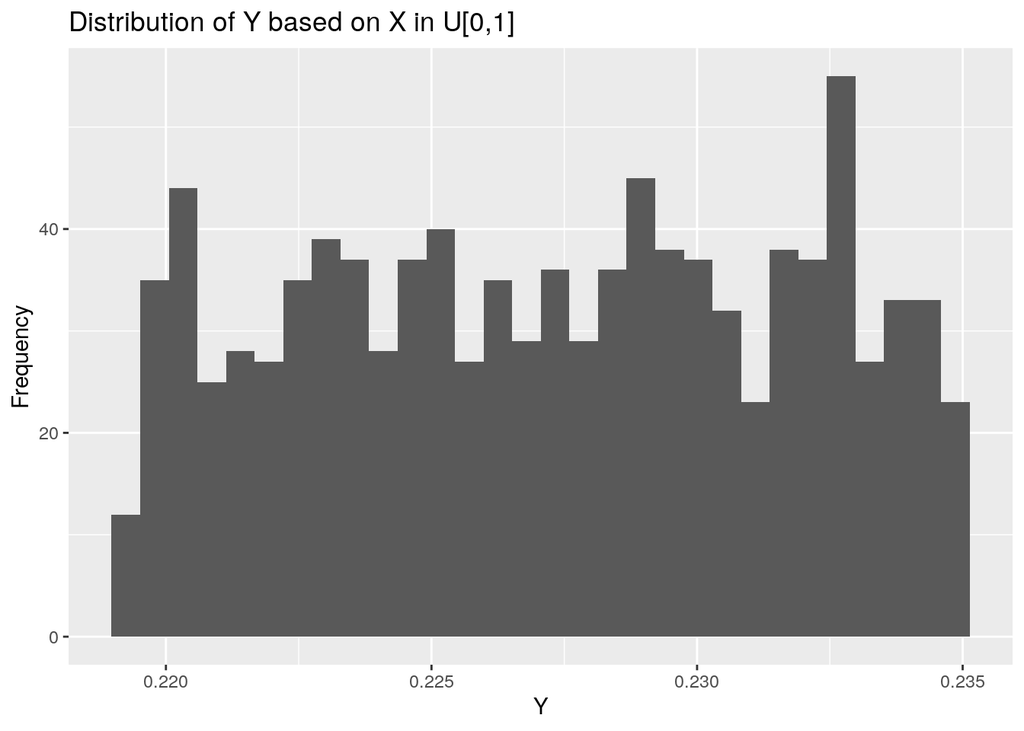

```r
qplot(y2, geom = "histogram", xlab = "Y", ylab = "Frequency") + ggtitle("Distribution of Y based on X in U[0,1]")
```